# Climate data analysis for climate risk reduction with R

By Michale Gebrekiors

May, 2024

# Data import

- Let us import the daily rainfall data using read.csv( ) function.

```r
Mydata<-read.csv("D:/ClimateRiskReduction/Data/ClimateData/RainFallData/Daily_Rainfall_Data_for_32_Met_Stations.csv",header=TRUE)
```

We can see the head and tail of our daily data (1992 to 2016) of 32 stations

```r
head(Mydata,1)
        date Abiadi Addiszemen Adidairo Adigrat Adigudom Adiremets Adishehu Adwa
  1 1/1/1992     NA         NA       NA      NA       NA        NA       NA   NA
    Ageregenet Agibe Aksum Ambagiorgis Atsbi ChenekST Debark Edagahamus Enfranz
  1         NA    NA    NA          NA    NA       NA     NA         NA       0
    GonderAP Hagereselam Hawzen Humera Korem Lalibela Maichew Maitsebri
  1        0          NA     NA     NA    NA       NA      NA        NA
    Maksegnite MekelleAP Nefasmawcha sheraro Shire Soketa Wukro
  1          0         0           0      NA    NA     NA    NA
```

```r
tail(Mydata,1)
             date Abiadi Addiszemen Adidairo Adigrat Adigudom Adiremets Adishehu
  9132 31-12-2016      0          0       NA       0       NA        NA       NA
       Adwa Ageregenet Agibe Aksum Ambagiorgis Atsbi ChenekST Debark Edagahamus
  9132    0          0    NA    NA           0     0       NA     NA         NA
       Enfranz GonderAP Hagereselam Hawzen Humera Korem Lalibela Maichew
  9132       0       NA           0     NA     NA    NA       NA       0
       Maitsebri Maksegnite MekelleAP Nefasmawcha sheraro Shire Soketa Wukro
  9132         0          0         0           0       0     0      0     0
```

## Make a date format

```r
Sta <- "1992-01-01" # start date
End <- "2016-12-31" # end date
date <- seq( from=as.Date(Sta), to =as.Date(End), by="days")#generate dates by day
Mydata$date<-date # change col one to date format
```

if we see head of our data, column one is changed to date format

```r
head(Mydata,1)# col one and row one
          date Abiadi Addiszemen Adidairo Adigrat Adigudom Adiremets Adishehu
  1 1992-01-01     NA         NA       NA      NA       NA        NA       NA
    Adwa Ageregenet Agibe Aksum Ambagiorgis Atsbi ChenekST Debark Edagahamus
  1   NA         NA    NA    NA          NA    NA       NA     NA         NA
    Enfranz GonderAP Hagereselam Hawzen Humera Korem Lalibela Maichew Maitsebri
  1       0        0          NA     NA     NA    NA       NA      NA        NA
    Maksegnite MekelleAP Nefasmawcha sheraro Shire Soketa Wukro
  1          0         0           0      NA    NA     NA    NA
```

## make a time series

- zoo package can be installed using install.packages ("zoo")
- and load it

```r
library(zoo)## an R-package for time series

  Attaching package: 'zoo'
  The following objects are masked from 'package:base':

      as.Date, as.Date.numeric
```

```r
MyDataTS <- zoo(Mydata[,-1],Mydata[,1])# chaning to zoo class
str(MyDataTS)# see it structure
  'zoo' series from 1992-01-01 to 2016-12-31
    Data: num [1:9132, 1:32] NA NA NA NA NA NA NA NA NA NA ...
   - attr(*, "dimnames")=List of 2
    ..$ : NULL
    ..$ : chr [1:32] "Abiadi" "Addiszemen" "Adidairo" "Adigrat" ...
    Index:  Date[1:9132], format: "1992-01-01" "1992-01-02" "1992-01-03" "1992-01-04" "1992-01-05" ...
```

We can see head of our time series

```r
head(time(MyDataTS))
  [1] "1992-01-01" "1992-01-02" "1992-01-03" "1992-01-04" "1992-01-05"
  [6] "1992-01-06"
```

see start and end time of our time series

```r
start(MyDataTS)# start date  of data series
  [1] "1992-01-01"
end(MyDataTS)# end date of data series
  [1] "2016-12-31"
```

see the names of the stations

```r
names(MyDataTS)
   [1] "Abiadi"      "Addiszemen"  "Adidairo"    "Adigrat"     "Adigudom"
   [6] "Adiremets"   "Adishehu"    "Adwa"        "Ageregenet"  "Agibe"
  [11] "Aksum"       "Ambagiorgis" "Atsbi"       "ChenekST"    "Debark"
  [16] "Edagahamus"  "Enfranz"     "GonderAP"    "Hagereselam" "Hawzen"
  [21] "Humera"      "Korem"       "Lalibela"    "Maichew"     "Maitsebri"
  [26] "Maksegnite"  "MekelleAP"   "Nefasmawcha" "sheraro"     "Shire"
  [31] "Soketa"      "Wukro"
```

As example we can see time series plots of three stations

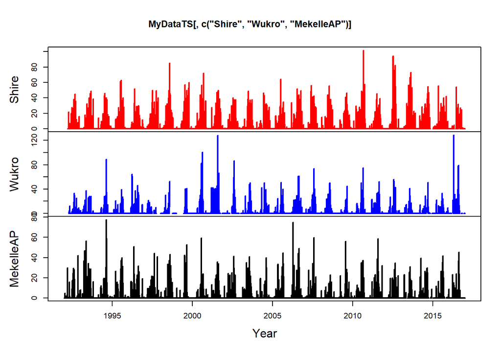

```r
plot(MyDataTS[,c("Shire","Wukro","MekelleAP")],col=c("red","blue","black"),xlab="Year",lwd=2)
```

Let's us go further by a selecting a single station for Wukro city

```r
Mystation<-MyDataTS[,"Wukro"]# select a single station
```

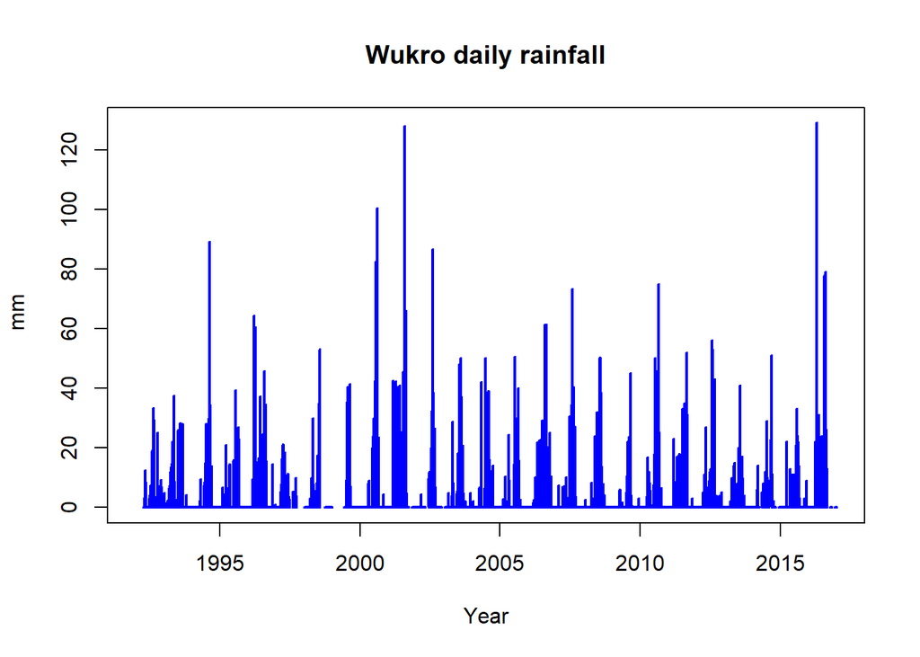

```r
plot(Mystation,main="Wukro daily rainfall", col="blue",xlab="Year",ylab= " mm",lwd=2)
```

```r
mean(Mystation)
  [1] NA
```

Why NA when we try to calculate mean? because of the availability of missing values in our data. missing in R is represented by NA. What about if we add one argument in the mean function in R

```r
mean(Mystation,na.rm=TRUE)# the NA is removed here
  [1] 1.707305
```

# Data cleaning

## Identify Missing Values

Typical data quality problems can be revealed by basic data summaries

```r
summary(Mystation)
       Index              Mystation
   Min.   :1992-01-01   Min.   :  0.000
   1st Qu.:1998-04-01   1st Qu.:  0.000
   Median :2004-07-01   Median :  0.000
   Mean   :2004-07-01   Mean   :  1.707
   3rd Qu.:2010-10-01   3rd Qu.:  0.000
   Max.   :2016-12-31   Max.   :129.000
                        NA's   :741
```

The daily rainfall is missing for 741 days it is about a 8% of the data. Why? Is it due to raingauge failure in theses days ? Did the meteorlogical agency failed in collecing rainfall for these days ? The perecent of missing can be found as follows

```r
n <-length(Mystation)# number of data
n
  [1] 9132
```

we can use functions like is.na() to identify missing. it gives us logical values TRUE and FALSE which are equivalent to the numeric values 1 and 0 and therefore the sum() and other functions can be used to obtain useful information about missing data. see the following:

```r
nm<- sum(is.na(Mystation))# number of missing data
nm
  [1] 741
```

```r
pm<- (nm/n)*100 # percent of missing
pm
  [1] 8.114323
```

when were the missing values? at the begining,end or in the middle of the recorded periods? we can see them with the following code dipicted in red points.

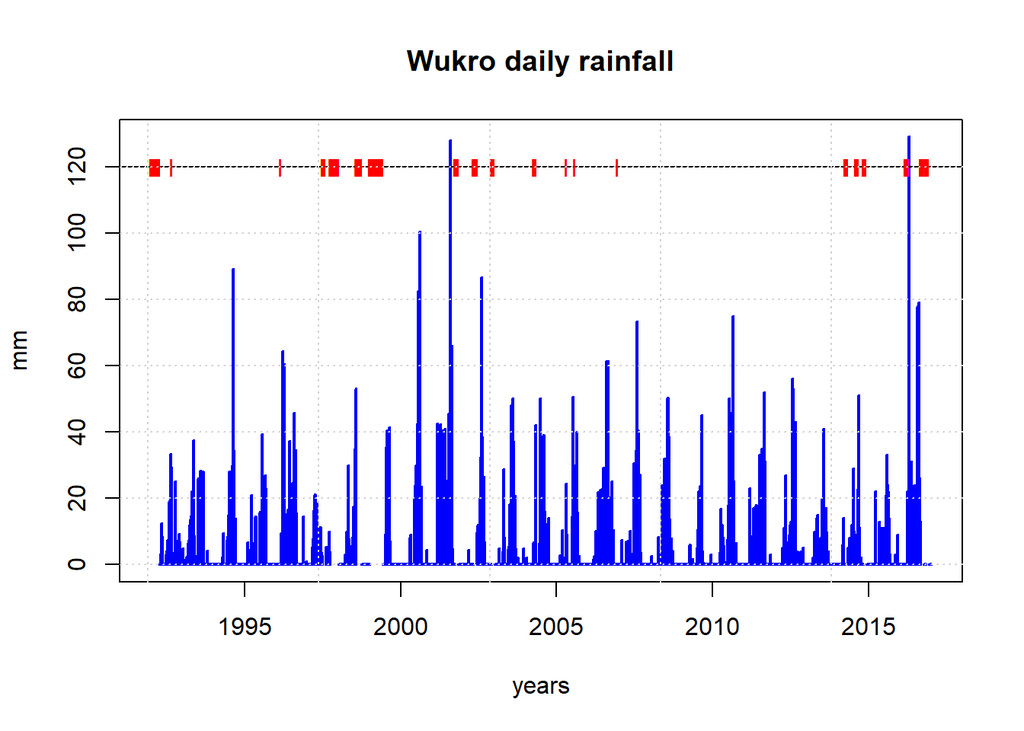

```r
plot(Mystation,  main  =  "Wukro daily rainfall", col="blue",lwd=2, ylab  =  "mm",xlab="years")
abline(h  =  120,  col  =  "black")
points(xy.coords(x  =  time(Mystation),  y  =  120,  recycle  =  T),pch  =  ifelse(is.na(Mystation),  "l",  ""),  col  =  "red")
grid()
```

## Decision on missing data

Whatever the reason for missing daily rainfall data, we should decide on the most acceptable action in our model. We have three options

- Do we select only periods with continous data? or
- Do we convert the missing values to mean or to another values?
- Do we drop all the rows where our rainfall data is missing?

There are a lot of methods for handiling missing data in climatology and hydrology in which we will discuss it in another topic . In this Wukro city, we might decide to drop the data rows with missing data about daily rainfall since there are less than 10% .

# Converting daily to lower temporal scale

## To monthly totals

*we have a program saved as DailyTomonthly.R in the RCode directory.

```r
source("D:/ClimateRiskReduction/RCode/DailyTomonthly.R")
```

```r
m<-DailyTomonthly(Mystation,sum,na.rm = TRUE)
```

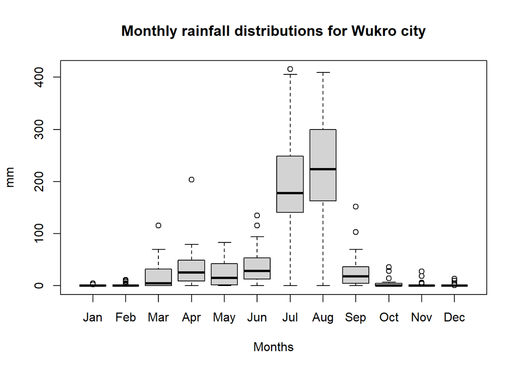

```r
M <- matrix(m, ncol=12, byrow=TRUE)
colnames(M) <- month.abb
rownames(M) <- unique(format(time(m), "%Y"))
boxplot(M,main="Monthly rainfall distributions for Wukro city",xlab="Months",ylab="mm")
```

```r
## Daily to annual
source("D:/ClimateRiskReduction/RCode/DailyToAnnual.R")
```

## To annual totals

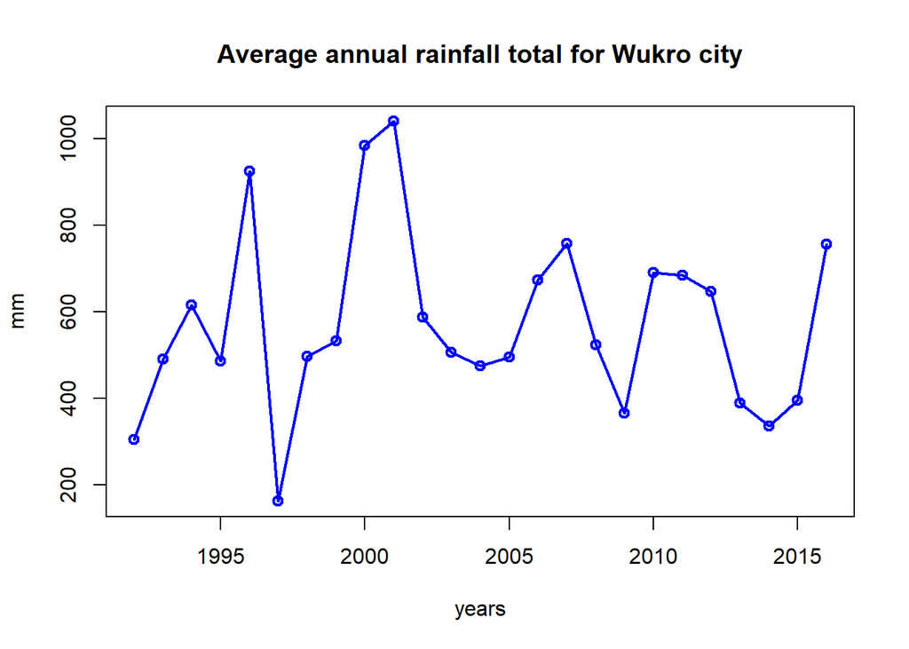

```r
A<-DailyToAnnual(Mystation,sum,na.rm = TRUE)
plot(A,main="Average annual rainfall total for Wukro city",type="o",lwd=2,col="blue",xlab="years",ylab="mm")
```